# Project 2

### Model Comparision Summary

#### Top 5 Variables from Each Model:

```
##     log.vars  tree.vars   bag.vars    rf.vars     gbm.vars
## 1 NREmployed NREmployed        Age        Age   NREmployed
## 2   pOutcome   pContact NREmployed  Euribor3M    Euribor3M
## 3      Month         NA  Euribor3M        Job          Age
## 4    Contact         NA   Campaign NREmployed     pContact
## 5        Day         NA        Job  Education ConsConfIndx
```

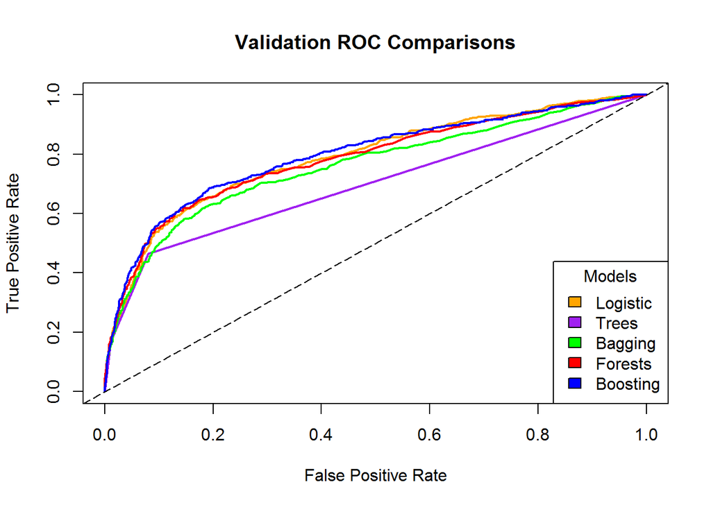

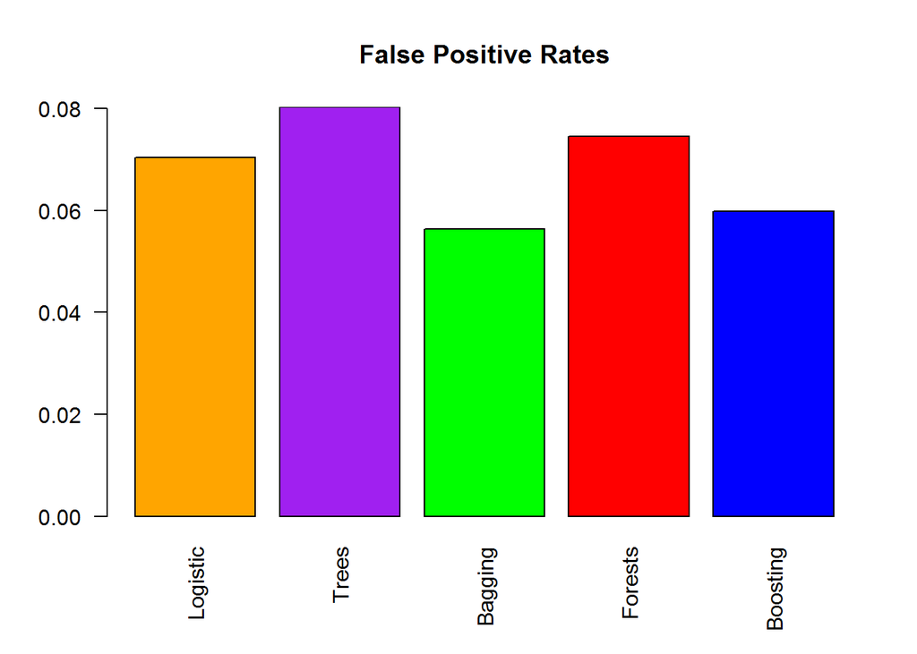

```
##        mod      a
## 1 Logistic 0.0704
## 2    Trees 0.0803
## 3  Bagging 0.0564
## 4  Forests 0.0745
## 5 Boosting 0.0599
```

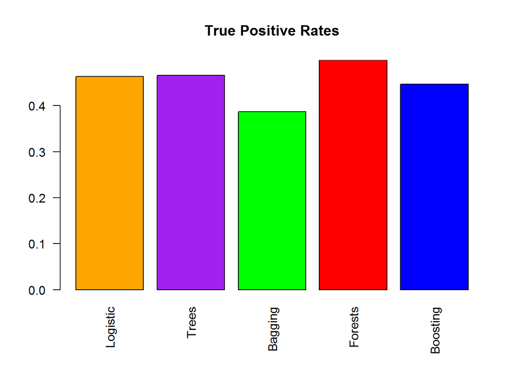

```
##        mod      a
## 1 Logistic 0.4636
## 2    Trees 0.4657
## 3  Bagging 0.3867
## 4  Forests  0.499
## 5 Boosting  0.447
```

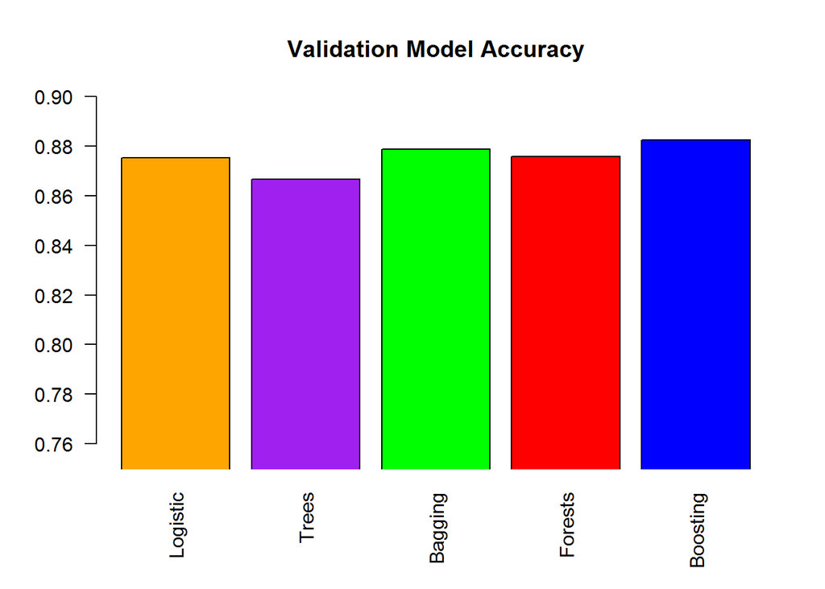

```
##        mod      a
## 1 Logistic 0.8752
## 2    Trees 0.8667
## 3  Bagging 0.8786
## 4  Forests 0.8757
## 5 Boosting 0.8825
```

### Model Testing

#### Logistic:

```r
log.test =  predict(log.mod,test,type="response")
x = confusion.matrix(uc.test, log.test, log.cut)[1:2,1:2] #create a confusion matrix
x
```

```
##     obs
## pred     0    1
##    0 17121 1194
##    1  1199 1081
```

#### Classification Trees:

```r
tree.test = predict(p.tree.mod,newdata=test,type="prob")[,2]
x = confusion.matrix(uc.test, tree.test, tree.cut)[1:2,1:2]
x
```

```
##     obs
## pred     0    1
##    0 16938 1186
##    1  1382 1089
```

#### Bagging:

```r
bag.test = predict(bagging.mod,test,type="prob")[,2]
x = confusion.matrix(uc.test,bag.test, bag.cut)[1:2,1:2]
x
```

```
##     obs
## pred     0    1
##    0 15642 1369
##    1  2678  906
```

```r
bag.t.tpr = round(x[2,2]/(x[1,2] + x[2,2]),4)
bag.t.fpr = round(x[2,1]/(x[2,1] + x[1,1]),4)
bag.t.accuracy = round((x[1,1] + x[2,2])/(x[1,1] + x[1,2] + x[2,1] + x[2,2]),4)
bag.t.pred = prediction(bag.test,test$Subscribed)
bag.t.perf = performance(bag.t.pred,"tpr","fpr")
```

#### Random Forests:

```r
rf.test = predict(rf.mod,test,type="prob")[,2]
x = confusion.matrix(uc.test, rf.test, rf.cut)[1:2,1:2]
x
```

```
##     obs
## pred     0    1
##    0 16753 1104
##    1  1567 1171
```

```r
rf.t.tpr = round(x[2,2]/(x[1,2] + x[2,2]),4)
rf.t.fpr = round(x[2,1]/(x[2,1] + x[1,1]),4)
rf.t.accuracy = round((x[1,1] + x[2,2])/(x[1,1] + x[1,2] + x[2,1] + x[2,2]),4)
rf.t.pred = prediction(rf.test,test$Subscribed)
rf.t.perf = performance(rf.t.pred,"tpr","fpr")
```

#### Boosting:

```r
boost.test = predict(gmb.model, test2, n.trees=ntrees,interaction.depth=depth,shrinkage=shrink
                      , type="response")
x = confusion.matrix(test2$Subscribed2, boost.test,gbm.cut)[1:2,1:2]
x
```

```
##     obs
## pred     0    1
##    0 17546 1389
##    1   774  886
```

```r
gbm.t.tpr = round(x[2,2]/(x[1,2] + x[2,2]),4)
gbm.t.fpr = round(x[2,1]/(x[2,1] + x[1,1]),4)
gbm.t.accuracy = round((x[1,1] + x[2,2])/(x[1,1] + x[1,2] + x[2,1] + x[2,2]),4)
gbm.t.pred = prediction(boost.test,test$Subscribed)
gbm.t.perf = performance(gbm.t.pred,"tpr","fpr")
```

### Model Comparision Summary

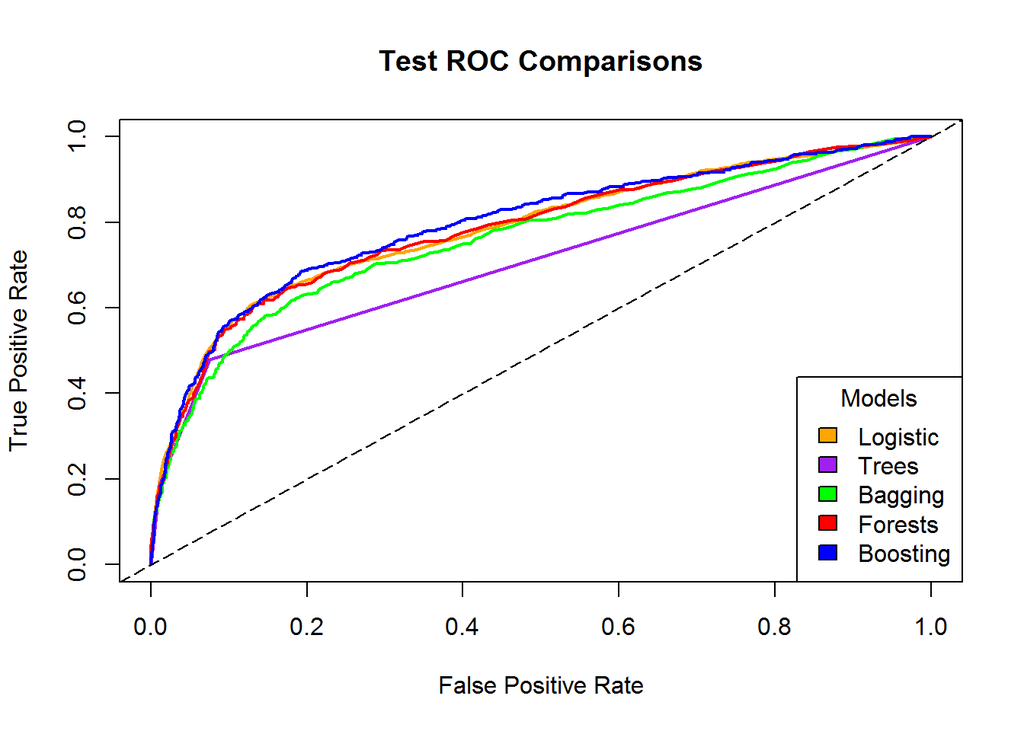

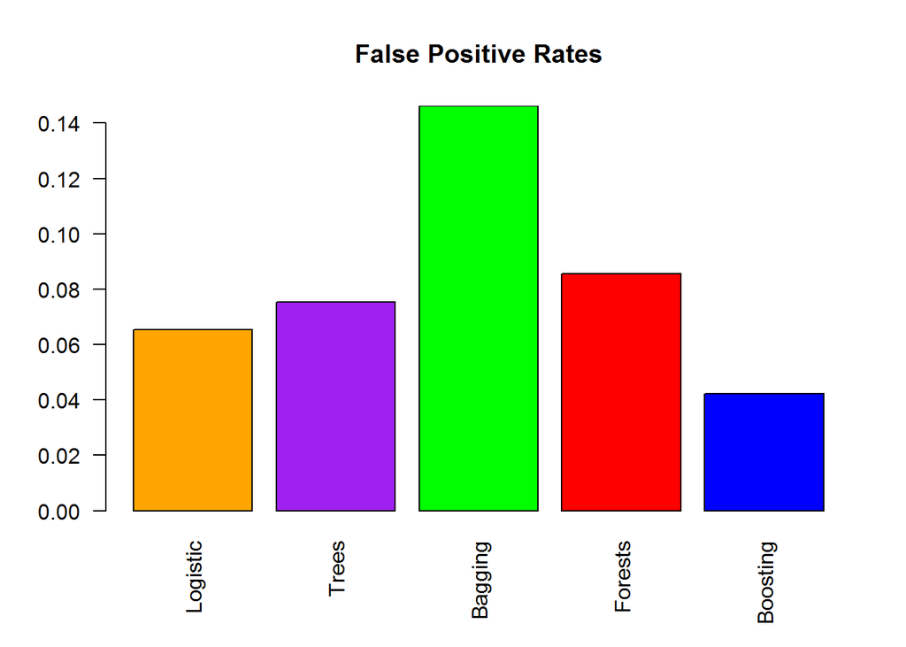

```
##        mod      a
## 1 Logistic 0.0654
## 2    Trees 0.0754
## 3  Bagging 0.1462
## 4  Forests 0.0855
## 5 Boosting 0.0422
```

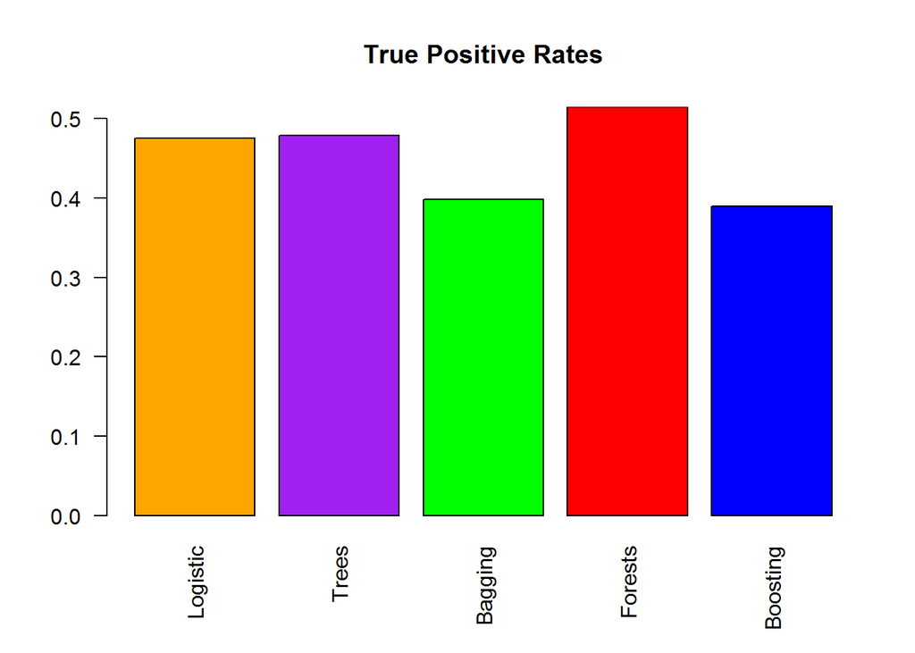

```
##        mod      a
## 1 Logistic 0.4752
## 2    Trees 0.4787
## 3  Bagging 0.3982
## 4  Forests 0.5147
## 5 Boosting 0.3895
```

[figure not shown]

```
##        mod      a
## 1 Logistic 0.8838
## 2    Trees 0.8753
## 3  Bagging 0.8035
## 4  Forests 0.8703
## 5 Boosting  0.895
```

#### Results

As we anticipated, the Gradient Boosting Model had the best performance on the Test Data: it had the lowest False Positive Rate and highest accuracy. The fact that it had the lowest True Positive Rate is not concerning as our assumptions guided us to mimimize the False Positives. Interestingly, the Bagging model did not perform nearly as well as anticipated. Its False Positive Rate was the highest and its accuracy was the lowest. Perhaps the model was overfit, which is always a conern with Bagging. Instead, the Logistic Model was second best: it had the second lowest False Positive Rate, almost tied for second highest True Positive Rate, and the second highest Accuracy.

### Conclusion

We have developed several classification models to predict a binary response. Each of the models we used have particular aspects that must be tuned to ensure the model performs well on unseen data. Even when these models are properly tuned, they must also be adapted to the inherient costs and tradeoffs of False Positives and False Negatives. In this case, we choose to minimize False Positives and tuned our models accordingly.